# Open Street Map, Data Wrangling with Mongo DB

#### Author: Ashley Goodman

##### Map Area: Hampton Roads, Virginia, United States

https://goo.gl/f2hfpQ

I selected the Hampton Roads area as its where I grew up, but left 20 years ago. I thought I would take the opportunity this project presents to indulge in some nostalgia.

#### My analysis process

Note: at the end of the document is a list of links to the various files and scripts used in inspecting, cleaning and shaping the data. I have linked to them as, due to file size, they would take too long to upload and may be larger than the allowed file submission size

#### Step 1: Creating smaller sample files

I sampled using the provided code found in the project setup materials: https://goo.gl/INY68X

My initial sample was at a "k" rate of 500, meaning my sample included every 500th entry

The resulting file: sample.osm is included in the link list.

I also made 2 other samples at a "k" rate of 100 and 10. These files are also included as sample2.osm and sample3.osm respectively.

The cells below contain some setup python for the coming scripts I use to examine the data for problems, clean, shape and finally export as JSON

I elected to examine and clean the data before exporting it into MongoDb. I could have imported the data first and then examined and cleaned it, but I preferred to know more about my data and any potential problems before importing it so I used python to examine the data in various ways as shown below.

#### Step 2 : Examine the files, starting with the smaller sample file and working up to the larger one for different types of key data including problem characters

I used the scripts provided/created during the case study running up to this project some of which I changed and refined as well as some new scripts

The types of keys scaled roughly with the "k" size of the file

One notable result was 3 problem characters found only when examining the full file, they were not present in the sample files.

I then ran the "key_type" and "initial_process_map" code on each sample file and finally the full file.

With the following results from the final file

```
{'problemchars': 3, 'lower': 1035119, 'other': 26692, 'lower_colon': 1900553}
```

#### Step 4: examine problem characters

I decided to examine the 3 problem characters more closely using the "process_prob_char" script.

Which gave the following output

```
['commit message', 'org.pcanet:ref', 'org.pcanet:presbytery']
```

#### Step 5: A closer look at the problem characters

I look online for references to "pcanet" and osm, but was unable to find any. I decided to look at the entry in the original osm (xml) file.

The challenge was finding a text editor that could handle such a large file. I ended up using EMEditor after some trial and error.

It turned out that the problem characters were found on only one entry so I manually edited (deleted) the sections of the entry as they added no information of value to the data set for the purposes of my analyis. The resulting file: "hamptonRoadsVirginiaManEdit2.osm" is included in the link list.

#### Step 6: Examine street names for potential cleaning

I examined in stages again, working my way up from the smallest sample file to the full file using the scripts for auditing street names. I established an initial list of expected street names and excluded them from my results so only unexpected names would show. With each stage I expanded the expected list until only problem names were left

The resulting output showed me a list like the incomplete example below:

```
'COURT', 'DRIVE', 'Rd', 'STREET, 'GREEN', 'AVENUE',
```

#### Step 7: Manual inspection of some of the problem names

I noticed that some of the problem names were one-of's and were more data entered incorrectly (for example suite numbers included with the street name) rather than mispellings, abbreviations etc.. So I decided to take a manual peek.

A manual inspection confirmed this to be the case and so for 14 of the entries I manually edited the osm file rather than write code to correct them as it would take longer to write the code and I was already looking at them.

Were I to look at multiple areas in an analysis instead of just the one I would probably look at writing code to handle the edits programatically, but as I was just inspecting one area a manual solution was more time efficient.

Here are a 5 examples of the 14 one-of's I manually edited

1. "Pickett's": set(["Pickett's"]) Which became Picketts's Line
2. '23529': set(['Parker Ave, Norfolk, VA 23529']), Which became Parker Avenue
3. '9': set(['Crusader Circle #9']) Which became Crusader Circle
4. ''45th': set(['45th']) Which became a variety of street names depending on the surrounding tag data and a Google map checks
5. 'Complex': set(['Krishana Complex']), was deleted as its actually an address in India

Of all of them the last one was most interesting as it was actually an address in India. As a guess I would imagine it was a misguided attempt at SEO.

For each edit I took the time to confirm the data using Google Maps and made sure that items like Suite numbers etc. were added as tags when stripped out of the street name if they were not already present.

In total this process took less than 30 minutes.

It also afforded me the opportunity to look more closely at the data and identify a number of other issues including:

1. Place and Street names in all caps
2. Multiple zip code tag types (as examined further below)
3. Multiple city tag types (as examined further below)

After the manual edit I updated my list of expected names and performed a final check of street names with the final problem name output shown below

```
'COURT', 'DRIVE', 'Rd', 'STREET, 'GREEN', 'AVENUE, 'SOUTH', 'LANE', 'NORTH', 'Hwy', 'Dr', 'ROAD','BOULEVARD', 'QUAY',
'St', 'PLACE', 'WAY', 'HIGHWAY', 'Blvd.', 'pwky', 'street', 'Blvd', 'Ave', 'Ct'
```

After the manual edits I was left with 0 problem characters and a clear set of street types to look at for cleaning programatically

#### Step 8: Postal codes

As mentioned above there are 3 tag types for post codes

1. The expected: addr:postcode
2. and the unexpected tiger:zip_right
3. and tiger:zip_left

I searched the OSM wiki for more information on the tiger data: https://goo.gl/XQ4Qbb

The data is outdated (imported in 2007) and will not be imported again.

I read further to see how others have handled the zip_right and left and found no consensus

1. https://goo.gl/9pf3oY
2. https://goo.gl/UwJePH

I decided to create 3 sets and examine them using the postcodes script

This resulted in a complete set of postcodes which allowed me to identify problem areas. (shown in the code file linked to at the bottom of this document)

1. Postcodes with 2 post codes, for example '23325:23523'
2. Postcodes with the state abbreviation prepended, for example 'VA 23455'
3. Postcodes with more than 5 digits, for example '23669-4019'

I examined the full data file manually again and noticed that the zip_right and zip_left were almost always identical for the same entry and that they generally never occured in entries that had addr:postcode

I decided that I would take addr:postcode as the primary source for post codes and where it was lacking would use zip_right

#### Step 9: Look at city names

I decided to look at all 3 tag types for city names

Aside from the addr:city tag there was also the following 2 tags

1. gnis:county_name
2. tiger:county

Looking at the output from the "process_city_names" script the above I noticed several issues

1. Capitalization like newport news instead of Newport News
2. Appending (city) to the city name for example, Hampton (city)
3. The final part of the name was missing where the entry was Isle of Wight instead of Isle of Wight County
4. Multiple city names as one entry like: James City, VA:York, VA
5. Appending the state to the city name like Newport News, VA
6. Mispellings like Noroflk instead of Norfolk

From this I was able to determine that city names would need some cleaning as well for mispelling, capitalization, stripping of extra data like state names, extra characters like commas, city type in parens etc..

I also noticed some entries for North Carolina which while close to Virginia were not technically a part of Hampton Roads, also often in the case of the Tiger data multiple cities would be included in one entry. A look at the osm file showed that these were "ways" and as such acceptable, for example an entry for "Camden, NC:Chesapeake, VA:Currituck, NC" was for the Norfolk Southern Railway.

I now had to decide what data to use, when, how and where.

I created the 2 mappings to assist with the data cleaning process streetmapping and citymapping dictionairies (shown in the code file linked to at the bottom of this document)

#### Step 10: Cleaning and shaping the data

I decided that "addr" info would be used as the primary source, where it was lacking I would use "gnis" or "tiger" data.

The issues to address in my cleaning and shaping of the data would be

   ```
                36.8854858,
                -76.2086654
        ],
        "type" : "node",
        "id" : "39678633",
        address: {
                "street": "Some street",
                "city": "Some City",
                "postcode" : "23456"
                "state": "Virginia"

        "created" : {
                "uid" : "1505651",
                "changeset" : "32900513",
                "version" : "2",
                "user" : "CynicalDooDad",
                "timestamp" : "2015-07-27T03:08:42Z"
        }
   ```

Note

1. That the "pos" field will be floats, all other fields will be strings.
2. The "created" and "address" fields would be nested documents within each JSON document
3. The "pos"field would be an array as a nested document within each JSON document
4. A field created to identify the data type as "node" or "way". All other data types, like"relation" would be removed
5. In the case of ways, a nested document containing all "nd" refs as list
6. Fields like amenity, building, cuisine etc would be preserved

I used several scripts to clean and shape the data, all of which are shown in the code file linked to at the bottom of this document

I then used the "process_map" script to produce the actual JSON document ready for import into mongodb

This produced a document structure like this:

```
{
        "website" : "http://www.housecallcompany.com/",
        "name" : "House Call Company",
        "created" : {
                "uid" : "3692214",
                "changeset" : "38022933",
                "version" : "1",
                "user" : "iMarketSolutions",
                "timestamp" : "2016-03-23T15:48:24Z"
        },
        "pos" : [
                36.8272829,
                -76.4119434
        ],
        "phone" : "757-394-3403",
        "craft" : "hvac",
        "address" : {
                "city" : "Chesapeake",
                "state" : "VA",
                "street" : "Portsmouth Boulevard",
                "place" : "House Call Company",
                "postcode" : "23321",
                "housenumber" : "4200"
        },
        "type" : "node",
        "id" : "4075361588",
        "description" : "House Call Company is an AC, Electrical, Heating, and Plumbing company in Chesapeake, VA. "
}
```

#### Importing the JSON into MongoDb

```
    mongoimport --db osm_wrangle --collection hamptonroads --file hamptonRoadsVirginiaManEdit2.osm.json
```

### Step 11: Exploring the cleaned data

#### Basic Database info

- File size original OSM unzipped 1.2 GB
- File size Formatted JSON document 1.41GB
- Number of documents in the database: 5,860,214

  ```
    db.hamptonroads.find().count()
  ```

- Number of nodes in the database: 5,277,057

  ```
    db.hamptonroads.find({type:"node"}).count()
  ```

- Number of ways in the database: 582,277

  ```
    db.hamptonroads.find({type:"way"}).count()
  ```

#### Further database details

##### Number of unique users: 552

```
db.hamptonroads.distinct("created.user").length
```

##### Top 10 contributors:

```
db.hamptonroads.aggregate([{"$group":{"_id":"$created.user", "count":{"$sum":1}}},{"$sort":{"count":-1}}, {"$limit":10}])

{ "_id" : "Jonah Adkins", "count" : 1749549 }
{ "_id" : "jonahadkins_vabeach_imports", "count" : 1287809 }
{ "_id" : "jonahadkins_norfolk_imports", "count" : 800185 }
{ "_id" : "jonahadkins_hampton_imports", "count" : 519782 }
{ "_id" : "jonahadkins_suffolk_import", "count" : 319864 }
{ "_id" : "woodpeck_fixbot", "count" : 311197 }
{ "_id" : "jonahadkins_yorkcounty_import", "count" : 185614 }
{ "_id" : "Omnific", "count" : 176043 }
{ "_id" : "CynicalDooDad", "count" : 106603 }
{ "_id" : "RoadGeek_MD99", "count" : 60940 }
```

For the following items I will show a graph of the results rather than the direct query results

##### List of amenities ordered by count:

```
     db.hamptonroads.aggregate([{"$group":{"_id":"$amenity", "count":{"$sum":1}}},{"$sort":{"count":-1}}, {"$limit":10}])
```

The vast majority of documents do not have an amenity field: 5,849,612

Of those that do here the top 10 presented by number of occurences:

*See Amenities Graph Below*

##### Looking at the leisure tag next

```
     db.hamptonroads.aggregate([{"$group":{"_id":"$leisure", "count":{"$sum":1}}},{"$sort":{"count":-1}}])
```

Again the vast majority do not have a leisure tag 5,856,883

*See Leisure Graph Below*

##### Types of cuisine

```
db.hamptonroads.aggregate([{"$match": {"amenity":{"$exists":1}, "cuisine":{"$exists":1}}},{"$group":{ "_id": "$cuisine", "count":{"$sum":1}}},{"$sort":{"count":-1}}])
```

*See Cuisine Graph Below*

##### Top 20 places to eat by number of locations:

```
      db.hamptonroads.aggregate([{"$match": {"cuisine":{"$exists":1}}},{"$group":{ "_id": "$name", "count":{"$sum":1}}},{"$sort":{"count":-1}},{"$limit": 21}])
      (query limit 21 as item 12 had a null value for name)
```

*See Top Places to Eat Graph Below*

##### Top 5 places to get a burger

```
       db.hamptonroads.aggregate([{"$match": {"cuisine":"burger"}},{"$group":{ "_id": "$address.name", "count":{"$sum":1}}},{"$sort":{"count":-1}},{"$limit":5}])
```

*See Top 5 Burger Places Graph Below*

##### Top 5 pizza places

```
       db.hamptonroads.aggregate([{"$match": {"cuisine":"pizza"}},{"$group":{ "_id": "$address.name", "count":{"$sum":1}}},{"$sort":{"count":-1}},{"$limit":6}])
```

*See Top Five Pizzarias Graph Below*

##### Places of worship by religion

```
        db.hamptonroads.aggregate([{"$group":{ "_id": "$religion", "count":{"$sum":1}}},{"$sort":{"count":-1}}])
```

*See Religion Graph Below*

##### By denomination

```
        db.hamptonroads.aggregate([{"$match": {"amenity": "place_of_worship"}}, {"$group":{ "_id": "$denomination", "count":{"$sum":1}}},{"$sort":{"count":-1}}])
```

757 do not have a denomination specified

For those that do:

*See Denominations Graph Below*

##### Edits by year

```
        db.hamptonroads.aggregate([{"$project":{"year":{"$substr":["$created.timestamp",0,4]}}},   {"$group":{ "_id": "$year", "count":{"$sum":1}}},   {"$sort":{"count":-1}}  ])
```

*See Edits Per Year Graph Below*

Note: there is a definite trend upwards in number of edits per year with the last 2 years having over 2 million edits per year

#### Below are the graphs of the data

```python
#!/usr/bin/env python
# -*- coding: utf-8 -*-

import matplotlib.pyplot as plt
import numpy as np
import pandas as pd
import seaborn as sns
```

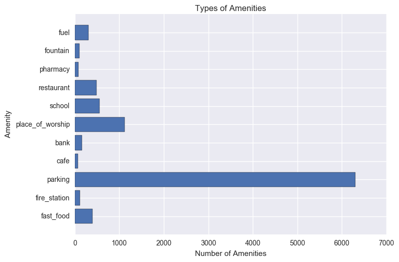

```python
amenities = {"parking": 6300,"place_of_worship": 1124,"school": 561,"restaurant": 488,"fast_food": 395,"fuel": 306,
             "bank": 163, "fire_station": 114, "fountain": 101,"pharmacy": 78,"cafe": 70,}

plt.barh(range(len(amenities)), amenities.values(),align ='center')
plt.yticks(range(len(amenities)), amenities.keys())
plt.subplots_adjust(bottom=0.2, top=1)
plt.title('Types of Amenities')
plt.xlabel('Number of Amenities')
plt.ylabel(' Amenity')
plt.ylim(-1, 11)
plt.show()
```

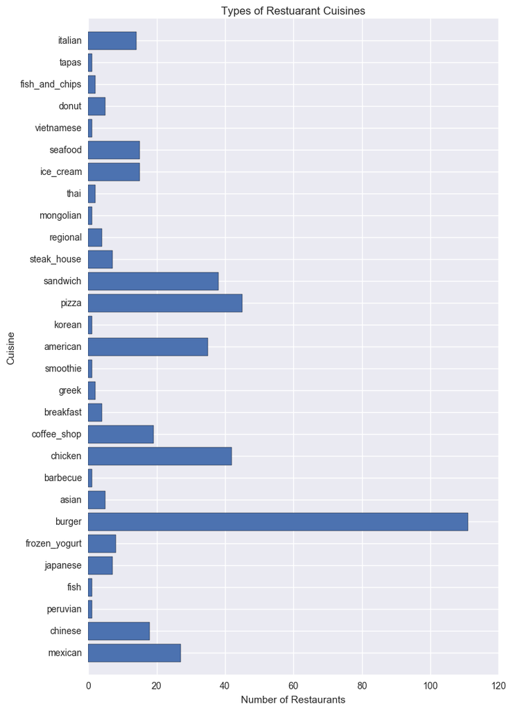

```python
cuisine_dict=  {"burger": 111, "pizza": 45,"chicken": 42, "sandwich": 38,"american": 35, "mexican": 27,"coffee_shop": 19,
                "chinese": 18,"ice_cream": 15,"seafood": 15,"italian": 14,"frozen_yogurt": 8,"asian": 5,"donut": 5,
                "steak_house": 7,"regional": 4,"japanese": 7,"greek": 2,"thai": 2,"fish_and_chips": 2, "peruvian": 1,
                "vietnamese": 1,"mongolian": 1,"korean": 1,"smoothie": 1,"tapas": 1, "barbecue": 1,"breakfast":4,"fish": 1,}

plt.barh(range(len(cuisine_dict)), cuisine_dict.values(),align ='center')
plt.yticks(range(len(cuisine_dict)), cuisine_dict.keys())
plt.subplots_adjust(bottom=0.2, top=2)
plt.title('Types of Restuarant Cuisines')
plt.xlabel('Number of Restaurants')
plt.ylabel('Cuisine')
plt.ylim(-1, 29)
plt.show()
```

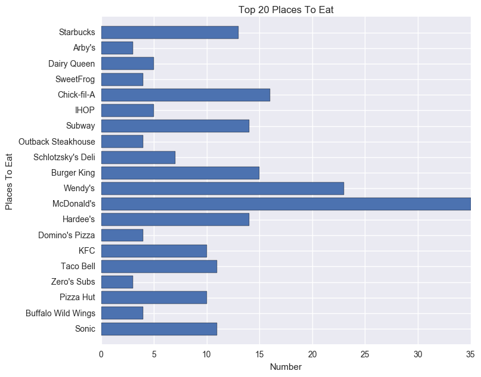

```python
places_to_eat = {"McDonald's": 35, "Wendy's": 23,"Chick-fil-A": 16, "Burger King": 15,"Hardee's": 14,"Subway": 14,
                 "Starbucks": 13,"Taco Bell": 11,"Sonic": 11,"KFC": 10, "Pizza Hut": 10,"Schlotzsky's Deli": 7,
                 "Dairy Queen": 5,"IHOP": 5, "Domino's Pizza": 4, "Buffalo Wild Wings": 4,  "SweetFrog": 4,
                 "Outback Steakhouse": 4,"Zero's Subs": 3, "Arby's": 3,}

plt.barh(range(len(places_to_eat)), places_to_eat.values(),align ='center')
plt.yticks(range(len(places_to_eat)), places_to_eat.keys())
plt.subplots_adjust(bottom=.5, top=1.5)
plt.title('Top 20 Places To Eat')
plt.xlabel('Number')
plt.ylabel('Places To Eat')
plt.ylim(-1, 20)
plt.show()
```

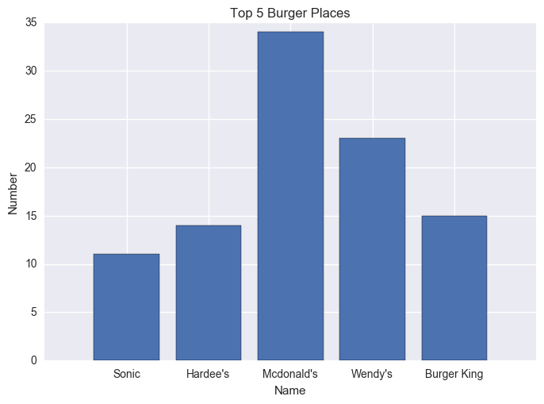

```python
top_5_burger ={"Mcdonald's": 34,"Wendy's": 23,"Burger King": 15,"Hardee's": 14,"Sonic": 11}


plt.bar(range(len(top_5_burger)), top_5_burger.values(),align ='center')
plt.xticks(range(len(top_5_burger)), top_5_burger.keys())
plt.title('Top 5 Burger Places')
plt.xlabel('Name')
plt.ylabel('Number')
plt.figure()
plt.show()
```

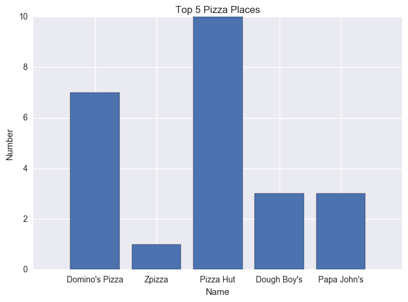

```python
top_5_pizzarias={ "Pizza Hut": 10,"Domino's Pizza": 7,"Papa John's": 3,"Dough Boy's": 3, "Zpizza": 1,}

plt.bar(range(len(top_5_pizzarias)), top_5_pizzarias.values(),align ='center')
plt.xticks(range(len(top_5_pizzarias)), top_5_pizzarias.keys())
plt.title('Top 5 Pizza Places')
plt.xlabel('Name')
plt.ylabel('Number')
plt.figure()
plt.show()
```

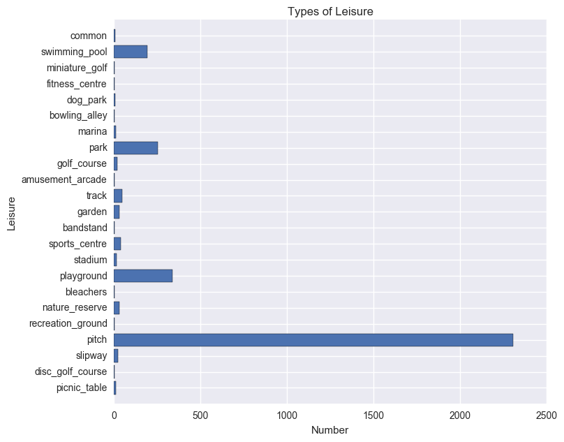

```python
leisure =  {"pitch": 2305, "playground": 336,"park": 251,"swimming_pool": 190,"track": 45, "sports_centre": 39,"garden": 30,
 "nature_reserve": 29, "slipway": 22, "golf_course": 20, "stadium": 13, "picnic_table": 11, "marina": 9,"dog_park": 6,
  "common": 6,"miniature_golf": 4, "bleachers": 4, "amusement_arcade": 3, "bandstand": 2, "recreation_ground": 2,
  "bowling_alley": 2, "fitness_centre": 1, "disc_golf_course": 1}

plt.barh(range(len(leisure)), leisure.values(),align ='center')
plt.yticks(range(len(leisure)), leisure.keys())
plt.subplots_adjust(bottom=.5, top=1.5)
plt.title('Types of Leisure')
plt.xlabel('Number')
plt.ylabel('Leisure')
plt.ylim(-1, 23)
plt.show()
```

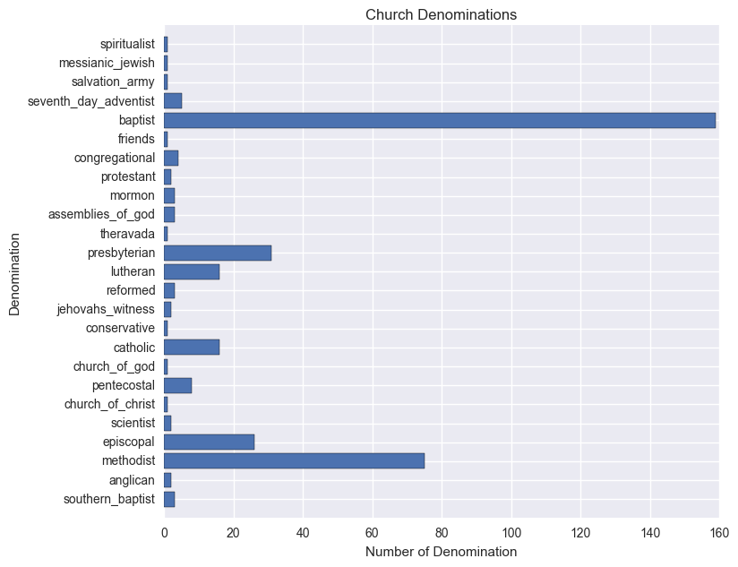

```python
denomination_dict = {"baptist":159, "methodist":75,"presbyterian":31, "episcopal":26,"lutheran":16,"catholic":16,"pentecostal":8,
                  "seventh_day_adventist":5, "congregational":4, "mormon":3, "assemblies_of_god":3,"southern_baptist":3,
                  "reformed":3, "protestant":2,"scientist":2,"anglican":2,"jehovahs_witness":2,"salvation_army":1,"friends":1,
                  "spiritualist":1, "theravada":1,"church_of_christ":1,"messianic_jewish":1,"conservative":1,"church_of_god":1}


plt.barh(range(len(denomination_dict)), denomination_dict.values(),align ='center' )
plt.yticks(range(len(denomination_dict)), denomination_dict.keys())
plt.subplots_adjust(bottom=0.5, top=1.5)
plt.title('Church Denominations')
plt.xlabel('Number of Denomination')
plt.ylabel('Denomination')
plt.ylim(-1, 25)
plt.figure()
plt.show()
```

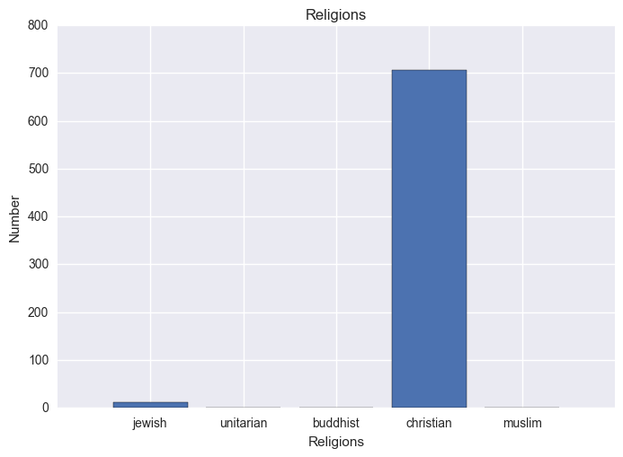

```python
religion_dict = {"christian" : 706,"jewish" : 11,"unitarian" : 1,"buddhist" : 1,"muslim" : 1,}
plt.bar(range(len(religion_dict)), religion_dict.values(),align ='center')
plt.xticks(range(len(religion_dict)), religion_dict.keys())
plt.title('Religions')
plt.xlabel('Religions')
plt.ylabel('Number')
plt.figure()
plt.show()
```

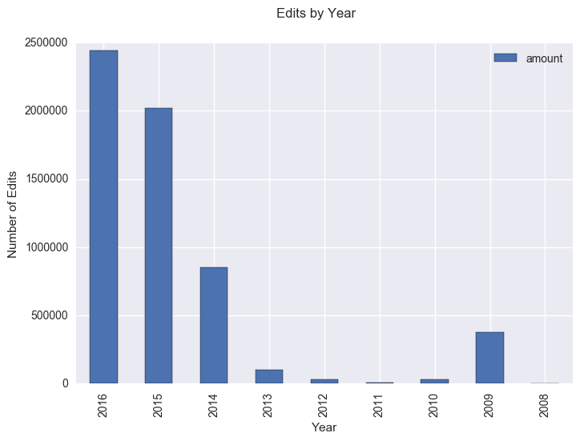

```python
edits_by_year_dict = {"2016": 2440836,"2015": 2016960,"2014": 850276,"2013": 99878,"2012": 30683,"2011": 5794,
                      "2010": 28675,"2009": 374560,"2008": 1119}


df=pd.DataFrame({
    'year':['2016','2015','2014','2013','2012','2011','2010','2009','2008'],
    'amount':[2440836,2016960,850276,99878,30683,5794,28675,374560,1119]
})


# Calculate the total amount for each year
df_grouped = df.groupby(['year']).sum().amount.reset_index()

# Use Stack Exchange trick to order days names in the table created by groupby:
# http://stackoverflow.com/questions/22635110/sorting-the-order-of-bars-in-pandas-matplotlib-bar-plots
years = ['2016', '2015', '2014', '2013', '2012', '2011', '2010','2009','2008']
mapping = {year: i for i, year in enumerate(years)}
key = df_grouped['year'].map(mapping)
df_grouped = df_grouped.iloc[key.argsort()]

# Draw the bar chart
df_grouped.plot(kind='bar', x='year')
plt.suptitle('Edits by Year')
plt.xlabel('Year')
plt.ylabel('Number of Edits')
plt.figure()
plt.show()
```

### Ideas for additional improvements

- An idea that came to me immediately was for a mobile app that semi-automates the process of updating the map using GPS, cross checking with other map apps and available online databases, like Four Square or even the Tiger database. I say semi automate as it would still require user confirmation that the data was correct before submission. This could be handled through a "check-in" process much like Facebook and Google and other apps currently use. It turns out that such an app does already exist "OSMTracker for Android" by Nicolas Guillaumin though it does not have the cross checking feature

##### To make this idea work really well a significant hurdles will need to be overcome.

- Name recogition: relatively few people have ever heard of Open Street Map. They rely on other services like Google Maps and are comfortable with the service they are using. Open Street Map needs to engage in some form of marketing for brand recognition and user adoption. Mozilla was able to do this with Firefox by encouraging extension and theme develeopment and attracting developers who in turn became "evangelizers" for Firefox. Open Street Map has an open API, but they need to do more to build a "marketplace/infrastructure" system that encourages developers to both develop and "evangalize" Open Street Maps bringing it more into the public eye, see gamification section for further thoughts on this.

##### Another idea for improvement is adopting standards

- Some standardization of data as it is input into OSM would be beneficial, for example if entering a node location, where applicable, requiring specifying if it is an amenity, a house/apartment building, for leisure etc. and disallowing entries with all caps or all lowercase before allowing the data to be saved would perhaps help avoid further incomplete or dirty (in the data sense) entries.

  The challenge here is that this is somewhat at odds with the Open Street Map ethos of "you are free to tag things how you want". If they want to become a serious player in accurate mapping a standard must be set and accepted by the community and rigorously applied. Wikipedia is a perfect example of this. It's open and anyone can make edits, however there are standards on everything from what is allowed as an entry to how entries are formatted, citations etc. and they are vigorously enforced by the community.

##### Gamification

- It has been mentioned in other analyses of Open Street map data for this very project, but I believe it is worth mentioning again with a more specific/literal interpretation:

  Partnering with other games/apps that already make use of map data or creating new apps that do could have multiple benefits.
  1. If those apps make use of another map source as primary, for example Google Maps, the data being entered into Gogle Maps by the app could be consideed a quality source and duplicated in OSM. For example Fitbit's use of maps for tracking running exercices
  2. Apps like Pokemon Go have shown how an app can motivate people to travel around their local areas, Partnering with such an app or creating one that can produce similar results could help collect/correct data in OSM. For example perhaps an app similar to Pokemon Go could have spawn points set not by arriving at a location but rather by entering a location in that does not yet exist in OSM or editing/correcting one that does.

     Businesses could also be encouraged to enter their data in as a spawn point to encourage mjore foot traffic.

     The completeness and type of data entered could determine the spawned creatures type/ strength/ stats and so on.

     There is risk that the system could be gamed with fake entries, but a wiki style approach requiring multiple independent verfication of the entered data combined with in game penalties if entered data is later proven falseified or external confimation using another source as canonical, like Google Maps, could help mitigate the risk.

##### Idea for further analysis

- Combining population census figures, crime rate figures and cost of living figures with city locations and using that to measure quality of life by the ratios of the number of schools, amenities, police departments, fire departments, leisure areas, grocery stores, malls, shops, churches etc.. by person and by dollar.

  There will be challenges with this as care will need to be taken to be sure that external data like cost of living and crime statistic info for a given locale will cover the same geographic area the Open Street Map of the same locale name does

  This will also require the Open Street Map data to be more complete, standardized and accurate or the quality of life conclusions drawn for an analysis will be mostly inaccurate.

### Conclusion

In as much as the quality and completeness of the Hampton Roads area Open Street Map data is representative of whole of OSM it is far from complete. It suffers from:

- Out of date data: for example much of the gnis and tiger data were mass automated imports and there are roads, buildings and even schools in the database that no longer exist
- Incomplete data: for example Chanello's pizza is easily in the top 5 pizza places, having over a dozen locations, yet has only 1 entry in the OSM data
- A lack of standardization which can make database queries difficult as the same data type might be recorded in different ways using different tag keys

#### Links to files and scripts

Please note, all are zipped to shorten download times and to avoid accidential execution of scripts

- make_sample.py script zipped https://goo.gl/QZd2je
- sample.osm https://goo.gl/N4V68Z
- sample2.osm https://goo.gl/rO3g54
- sample3.osm https://goo.gl/aOsvBh
- Original OSM file for Hampton Roads https://goo.gl/FKE6nX
- full_file (originalfile, renamed) https://goo.gl/Qb5WJJ
- man_edit (osm file after first manual edits https://goo.gl/exfKia
- man_edit2 (osm file after final round of manual edits https://goo.gl/6QrfiU
- JSON output of clean and shape scrips https://goo.gl/wFSr6C
- zipped python script file, contains all scripts used for this project https://goo.gl/3b7VQq